# Homework 5 POCOCK

Due Thursday, November 10 at 11:59:59pm

1. In the car_multi.csv file, there is a field called acceleration. Calculate

```r
cars_multi <- read.csv('cars_multi.csv')
```

1. The mean value

```r
acc_mean <- mean(cars_multi$acceleration)
print(acc_mean)
```

```
[1] 15.56809
```

2. The standard deviation

```r
acc_sd <- sd(cars_multi$acceleration)
print(acc_sd)
```

```
[1] 2.757689
```

```r
acc_se <- sd(cars_multi$acceleration)/sqrt(length(cars_multi$acceleration))
```

3. The 5th and 95th quantile

```r
quantile(cars_multi$acceleration, c(0.05,0.95))
```

```
    5%    95%
11.285 20.415
```

So the 5th : 11.285 The 95th : 20.415

2. For this acceleration field, assuming it is normally distributed, conduct a hypothesis test at the 95% confidence level to determine whether you can say the mean value is greater than 15.2. State the null hypothesis. Conduct the hypothesis test by
   - null hypothesis: the mean value less than or equal to 15.2.
1. Constructing an appropriate confidence interval

```r
se <- acc_sd/sqrt(length(cars_multi$acceleration))
mu <- acc_se*qt(0.95, length(cars_multi$acceleration-1))
```

2. Calculating a p-value, both by
3. Analytically

```r
t_val <- ((mu - 15.2) / acc_se)
pt <- pt(t_val, length(acc_se - 1))
pt
```

```
[1] 0.002938724
```

2. Running an appropriate simulation

```r
trials <- 10000
sampmean <- mu
n <- length(cars_multi$acceleration)
H0mean <- 15.2
sampse <- rep(0,trials)
for(i in 1:trials){
  simsamp <- H0mean + sampsd * rt(n, n-1)
  simmean[i] <- mean(simsamp)
}
p_value <- sum(abs(simmean - H0mean) > abs(sampmean - H0mean))/trials
p_value
```

```
[1] 0
```

3. A Poisson process generates the following data: {3, 5, 6, 7, 10, 4, 5, 6, 4, 3}, covering 2 second intervals. Run a Monte Carlo simulation to test the hypothesis at a 95% confidence that the rate parameter is greater than 2. null hypothesis: the rate parameter is greater than 2. one-sided

```r
samp <- c(3, 5, 6, 7, 10, 4, 5, 6, 4, 3)
#two second intervals  time_intervals <- c(0.2,0.4,0.6,0.8,1.0,1.2,1.4,1.6,1.8, 2.0)
#mean(samp) + sd(samp)/sqrt(length(samp)) * qt(0.955, length(samp)-1)

trials <- 100000
sampmean <- mean(samp)
H0mean <- 2.0
n <- length(samp)
p_value <- 0
simmean <- rep(0,trials)
for(i in 1:trials){
  simsamp <- rpois(n, H0mean)
  simmean[i] <- mean(simsamp)
}
p_value <- sum(simmean <= sampmean)/trials
p_value
```

```
[1] 1
```

4. For the 4 values you calculated in #1, construct 95% confidence intervals using
1. Regular bootstrapping

```r
acc_mean_ <- rep(0,10000)
acc_sd_ <- rep(0,10000)
#sample(cars_multi$acceleration, length(cars_multi$acceleration), replace = TRUE)
for(i in 1:10000){
  acc_samp_ <- sample(cars_multi$acceleration, length(cars_multi$acceleration), replace = TRUE)
  acc_mean_[i] <- mean(acc_samp_)
  acc_sd_[i] <- sd(acc_samp_)
}
quantile(acc_mean_, c(0.025, 0.975))
```

```
    2.5%    97.5%
15.30075 15.84273
```

2. Bayesian bootstrapping

```r
library(DirichletReg)
weight <- rep(0,length(cars_multi$acceleration))
accmean <- rep(0,10000)
accmedian <- rep(0,10000)
acc90 <- rep(0,10000)
accsd <- rep(0,10000)
for(i in 1:10000){
  weight <- rdirichlet(1, rep(1,length(cars_multi$acceleration)))
  accsamp <- sample(cars_multi$acceleration, length(cars_multi$acceleration), prob = weight, replace = TRUE)
  accmean[i] <- mean(accsamp)
  accsd[i] <- sd(accsamp)
}
quantile(accmean, c(0.025, 0.975))
```

```
    2.5%    97.5%
15.19041 15.95579
```

5. Import the data in the dataset called “longtail.csv.”

```r
longtail <- read.csv('longtail.csv')
longtail
```

| X | x |
| --- | --- |
| 1 | 1.109765 |
| 2 | 1.325751 |
| 3 | 3.066469 |
| 4 | 1.065976 |
| 5 | 1.140349 |
| 6 | 1.331422 |
| 7 | 1.808547 |
| 8 | 2.718561 |
| 9 | 56.755303 |
| 10 | 1.586783 |

[output cut: 990 more lines]

Calculate the standard deviation and the 0.99th quantile.

```r
lt_sd <- sd(longtail$x)
print(lt_sd)
```

```
[1] 78.97681
```

```r
lt_99 <- quantile(longtail$x, 0.99)
print(lt_99)
```

```
     99%
93.64829
```

Standard deviation = 78.97681

0.99th quantile = 93.64829

```r
#regular bootstrapping :
longtail_95 <- rep(0,10000)
longtail_sd <- rep(0,10000)
#sample(longtail$x, length(longtail$x), replace = TRUE)
for(i in 1:10000){
  longtail_samp <- sample(longtail$x, length(longtail$x), replace = TRUE)
  longtail_95[i] <- quantile(longtail_samp, 0.95)
  longtail_sd[i] <- sd(longtail_samp)
}
print(quantile(longtail_95, c(0.025, 0.975)))
```

```
    2.5%    97.5%
17.85688 20.88472
```

```r
print(quantile(longtail_sd, c(0.025, 0.975)))
```

```
     2.5%     97.5%
 50.62495 104.06567
```

```r
#c(0.005, 0.995)
```

```r
#baysian
library(DirichletReg)
lt_weight <- rep(0,length(longtail$x))
lt_mpg95 <- rep(0,10000)
lt_sd <- rep(0,10000)
for(i in 1:10000){
  weight <- rdirichlet(1, rep(1,length(longtail$x)))
  lt_samp <- sample(longtail$x, length(longtail$x), prob = weight, replace = TRUE)
  lt_mpg95[i] <- quantile(lt_samp, 0.95)
  lt_sd[i] <- sd(lt_samp)
}
quantile(lt_mpg95, c(0.025, 0.975))
```

```
    2.5%    97.5%
17.29623 21.86533
```

```r
quantile(lt_sd, c(0.025, 0.975))
```

```
     2.5%     97.5%
 42.66145 117.73960
```

6. #1, page 22, Bayesian Inference - 1. Let’s return to your game of ping-pong. Your friend thinks the possible values for 𝜃, your long-term probability of winning, are 0.4, 0.5, and 0.6, with probabilities 0.2, 0.6, and 0.2, respectively. Suppose you win four games out of five.

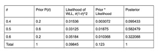

```r
#![something](/Downloads/STT380/table_stt380 Small.jpeg)
knitr::include_graphics('~/Downloads/STT380/table_stt_q6.jpeg')
```

2. Give a sentence interpreting the posterior probability for 𝜃 = 0.6. Since I won 4/5 of my games, winning 𝜃 = 0.6 is now going to be more probable compared to 0.2 since 4/5=0.8 whihc is closer to 0.6.
3. Find the prior and posterior expected values of 𝜃. How do they compare?

```r
prior <- 0.4*0.2 + 0.5*0.6 + 0.6*0.2
post <- 0.4*0.095433 + 0.5*0.582479 + 0.6*0.322088
print(prior)
```

```
[1] 0.5
```

```r
print(post)
```

```
[1] 0.5226655
```

7. #3, page 22-23, Bayesian Inference - Suppose the possible values of 𝜃 = your chances of winning a game of tennis are 0, 0.1, …, 1, with equal probabilities.
1. Fill out the rest of this table if you win four games out of seven

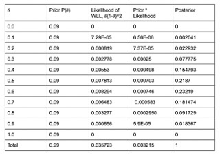

```r
knitr::include_graphics('~/Downloads/STT380/stt_table_q7.jpeg')
```

```r
NA
```

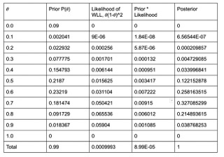

```r
knitr::include_graphics('~/Downloads/STT380/q7_last.jpeg')
```

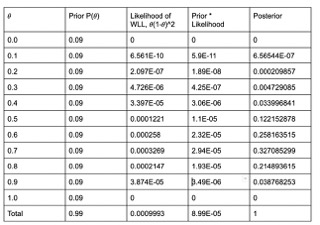

```r
knitr::include_graphics('~/Downloads/STT380/q7_next.jpeg')
```

```r
NA
```